# Assignment 2

Author

Ellya Gholmieh

## 1. Preparing the Data

```r
library(data.table)
library(dplyr)
chs_individual <- data.table::fread("C:/Users/ellya/OneDrive/Desktop/PM566labs/chs_individual.csv")
chs_regional <- data.table::fread("C:/Users/ellya/OneDrive/Desktop/PM566labs/chs_regional.csv")

chsdata <- merge(
  x = chs_individual,
  y = chs_regional,
  by.x = "townname",
  by.y = "townname",
  all.x = TRUE,
  all.y = FALSE
)

dim(chs_individual)
```

```
[1] 1200   23
```

```r
dim(chsdata)
```

```
[1] 1200   49
```

```r
str(chsdata)
```

```
Classes 'data.table' and 'data.frame':  1200 obs. of  49 variables:
 $ townname     : chr  "Alpine" "Alpine" "Alpine" "Alpine" ...
 $ sid          : int  835 838 839 840 841 842 843 844 847 849 ...
 $ male         : int  0 0 0 0 1 1 1 1 1 1 ...
 $ race         : chr  "W" "O" "M" "W" ...
 $ hispanic     : int  0 1 1 0 1 1 0 1 0 0 ...
 $ agepft       : num  10.1 9.49 10.05 9.97 10.55 ...
 $ height       : int  143 133 142 146 150 139 149 143 137 147 ...
 $ weight       : int  69 62 86 78 78 65 98 65 69 112 ...
 $ bmi          : num  15.3 15.9 19.4 16.6 15.8 ...
 $ asthma       : int  0 0 0 0 0 0 0 NA 0 0 ...
 $ active_asthma: int  0 0 0 0 0 0 0 0 0 0 ...
 $ father_asthma: int  0 0 0 0 0 0 0 NA 0 1 ...
 $ mother_asthma: int  0 0 1 0 0 0 0 NA 0 0 ...
 $ wheeze       : int  0 0 1 0 0 1 1 NA 0 1 ...
```

[output cut: 37 more lines]

```r
summary(chsdata)
```

```
   townname              sid              male            race
 Length:1200        Min.   :   1.0   Min.   :0.0000   Length:1200
 Class :character   1st Qu.: 528.8   1st Qu.:0.0000   Class :character
 Mode  :character   Median :1041.5   Median :0.0000   Mode  :character
                    Mean   :1037.5   Mean   :0.4917
                    3rd Qu.:1554.2   3rd Qu.:1.0000
                    Max.   :2053.0   Max.   :1.0000

    hispanic          agepft           height        weight
 Min.   :0.0000   Min.   : 8.961   Min.   :114   Min.   : 42.00
 1st Qu.:0.0000   1st Qu.: 9.610   1st Qu.:135   1st Qu.: 65.00
 Median :0.0000   Median : 9.906   Median :139   Median : 74.00
 Mean   :0.4342   Mean   : 9.924   Mean   :139   Mean   : 79.33
 3rd Qu.:1.0000   3rd Qu.:10.177   3rd Qu.:143   3rd Qu.: 89.00
 Max.   :1.0000   Max.   :12.731   Max.   :165   Max.   :207.00
                  NA's   :89       NA's   :89    NA's   :89
      bmi            asthma       active_asthma  father_asthma
 Min.   :11.30   Min.   :0.0000   Min.   :0.00   Min.   :0.00000
 1st Qu.:15.78   1st Qu.:0.0000   1st Qu.:0.00   1st Qu.:0.00000
 Median :17.48   Median :0.0000   Median :0.00   Median :0.00000
 Mean   :18.50   Mean   :0.1463   Mean   :0.19   Mean   :0.08318
 3rd Qu.:20.35   3rd Qu.:0.0000   3rd Qu.:0.00   3rd Qu.:0.00000
 Max.   :41.27   Max.   :1.0000   Max.   :1.00   Max.   :1.00000
 NA's   :89      NA's   :31                      NA's   :106
 mother_asthma        wheeze          hayfever         allergy
 Min.   :0.0000   Min.   :0.0000   Min.   :0.0000   Min.   :0.0000
 1st Qu.:0.0000   1st Qu.:0.0000   1st Qu.:0.0000   1st Qu.:0.0000
 Median :0.0000   Median :0.0000   Median :0.0000   Median :0.0000
 Mean   :0.1023   Mean   :0.3313   Mean   :0.1747   Mean   :0.2929
 3rd Qu.:0.0000   3rd Qu.:1.0000   3rd Qu.:0.0000   3rd Qu.:1.0000
 Max.   :1.0000   Max.   :1.0000   Max.   :1.0000   Max.   :1.0000
 NA's   :56       NA's   :71       NA's   :118      NA's   :63
  educ_parent        smoke             pets           gasstove
 Min.   :1.000   Min.   :0.0000   Min.   :0.0000   Min.   :0.0000
 1st Qu.:2.000   1st Qu.:0.0000   1st Qu.:1.0000   1st Qu.:1.0000
 Median :3.000   Median :0.0000   Median :1.0000   Median :1.0000
 Mean   :2.797   Mean   :0.1638   Mean   :0.7667   Mean   :0.7815
 3rd Qu.:3.000   3rd Qu.:0.0000   3rd Qu.:1.0000   3rd Qu.:1.0000
 Max.   :5.000   Max.   :1.0000   Max.   :1.0000   Max.   :1.0000
 NA's   :64      NA's   :40                        NA's   :33
```

[output cut: 48 more lines]

```
     iacid           oacid        total_acids          lon
 Min.   :0.760   Min.   :1.090   Min.   : 1.520   Min.   :-120.7
 1st Qu.:1.835   1st Qu.:2.978   1st Qu.: 4.930   1st Qu.:-118.8
 Median :2.825   Median :4.135   Median : 6.370   Median :-117.7
 Mean   :2.788   Mean   :4.342   Mean   : 6.708   Mean   :-118.3
 3rd Qu.:3.817   3rd Qu.:5.982   3rd Qu.: 9.395   3rd Qu.:-117.4
 Max.   :4.620   Max.   :7.400   Max.   :11.430   Max.   :-116.8

      lat
 Min.   :32.84
 1st Qu.:33.93
 Median :34.10
 Mean   :34.20
 3rd Qu.:34.65
 Max.   :35.49
```

```r
missing_continuous_data <- c("agepft", "height", "weight", "bmi", "fev", "fvc", "mmef", "no_24hr", "pm2_5_fr")
missing_categorical_data <- c("asthma", "father_asthma", "mother_asthma", "wheeze", "hayfever", "allergy", "educ_parent", "smoke", "gasstove")

mode <- function(x) {
  x <- na.omit(x)
  ux <- unique(x)
  ux[which.max(tabulate(match(x, ux)))]
}

chsdata <- chsdata |>
  group_by(male, hispanic) |>
  mutate(across(all_of(missing_continuous_data), ~coalesce(., mean(., na.rm = TRUE)))) |>
  mutate(across(all_of(missing_categorical_data), ~coalesce(., mode(.))))

setDT(chsdata)

chsdata[, obesity_level := sapply(1:nrow(chsdata), function(i){
  if(bmi[i] < 14){
    return('Underweight')
  }else if(bmi[i] >=14 & chsdata$bmi[i] < 22){
      return('Normal')
  }else if(bmi[i] >= 22 & chsdata$bmi[i] <= 24){
      return('Overweight')
  }else if(bmi[i] > 24){
      return('Obese')
    }
  }
)]

chsdata %>%
  group_by(obesity_level) %>%
  summarise(
  min_bmi = which.min(bmi),
  max_bmi = which.max(bmi),
  Entries = n()
  )
```

```
# A tibble: 4 × 4
  obesity_level min_bmi max_bmi Entries
  <chr>           <int>   <int>   <int>
1 Normal             22     203     975
2 Obese              12      74     103
3 Overweight         81      37      87
4 Underweight        32       1      35
```

```r
chsdata[, smoke_gas_exposure := sapply(1:nrow(chsdata), function(i){
  if(smoke[i] == 0 & gasstove[i] == 0){
    return('No Smoke/Stove')
  }else if(smoke[i] == 1 & gasstove[i] == 0){
      return('Only Smoke')
  }else if(smoke[i] == 0 & gasstove[i] == 1){
      return('Only Stove')
  }else if(smoke[i] == 1 & gasstove[i] == 1){
      return('Smoke and Stove')
    }
  }
)]

chsdata %>%
  group_by(smoke_gas_exposure) %>%
  summarise(
  Entries = n()
  )
```

```
# A tibble: 4 × 2
  smoke_gas_exposure Entries
  <chr>                <int>
1 No Smoke/Stove         219
2 Only Smoke              36
3 Only Stove             791
4 Smoke and Stove        154
```

```r
chsdata %>%
  group_by(townname) %>%
  summarise(
  fev_avg = mean(fev, na.rm = TRUE),
  fev_sd = sd(fev, na.rm = TRUE)
  )
```

```
# A tibble: 12 × 3
   townname      fev_avg fev_sd
   <chr>           <dbl>  <dbl>
 1 Alpine          2087.   291.
 2 Atascadero      2076.   324.
 3 Lake Elsinore   2039.   304.
 4 Lake Gregory    2085.   320.
 5 Lancaster       2003.   317.
 6 Lompoc          2034.   351.
 7 Long Beach      1986.   319.
 8 Mira Loma       1985.   325.
 9 Riverside       1990.   278.
10 San Dimas       2027.   319.
11 Santa Maria     2026.   312.
12 Upland          2024.   343.
```

```r
chsdata %>%
  group_by(male) %>%
  summarise(
  fev_avg = mean(fev, na.rm = TRUE),
  fev_sd = sd(fev, na.rm = TRUE)
  )
```

```
# A tibble: 2 × 3
   male fev_avg fev_sd
  <int>   <dbl>  <dbl>
1     0   1959.   312.
2     1   2104.   308.
```

```r
chsdata %>%
  group_by(obesity_level) %>%
  summarise(
  fev_avg = mean(fev, na.rm = TRUE),
  fev_sd = sd(fev, na.rm = TRUE)
  )
```

```
# A tibble: 4 × 3
  obesity_level fev_avg fev_sd
  <chr>           <dbl>  <dbl>
1 Normal          2000.   295.
2 Obese           2266.   325.
3 Overweight      2224.   317.
4 Underweight     1698.   303.
```

```r
chsdata %>%
  group_by(smoke_gas_exposure) %>%
  summarise(
  fev_avg = mean(fev, na.rm = TRUE),
  fev_sd = sd(fev, na.rm = TRUE)
  )
```

```
# A tibble: 4 × 3
  smoke_gas_exposure fev_avg fev_sd
  <chr>                <dbl>  <dbl>
1 No Smoke/Stove       2057.   329.
2 Only Smoke           2056.   296.
3 Only Stove           2023.   319.
4 Smoke and Stove      2025.   301.
```

## 2. Exploratory Data Analysis

```r
dim(chsdata)
```

```
[1] 1200   51
```

```r
head(chsdata)
```

```
   townname   sid  male   race hispanic    agepft height weight      bmi asthma
     <char> <int> <int> <char>    <int>     <num>  <num>  <num>    <num>  <int>
1:   Alpine   835     0      W        0 10.099932    143     69 15.33749      0
2:   Alpine   838     0      O        1  9.486653    133     62 15.93183      0
3:   Alpine   839     0      M        1 10.053388    142     86 19.38649      0
4:   Alpine   840     0      W        0  9.965777    146     78 16.63283      0
5:   Alpine   841     1      W        1 10.548939    150     78 15.75758      0
6:   Alpine   842     1      M        1  9.489391    139     65 15.29189      0
   active_asthma father_asthma mother_asthma wheeze hayfever allergy
           <int>         <int>         <int>  <int>    <int>   <int>
1:             0             0             0      0        0       1
2:             0             0             0      0        0       0
3:             0             0             1      1        1       1
4:             0             0             0      0        0       0
5:             0             0             0      0        0       0
```

[output cut: 33 more lines]

```r
tail(chsdata)
```

```
   townname   sid  male   race hispanic    agepft  height   weight      bmi
     <char> <int> <int> <char>    <int>     <num>   <num>    <num>    <num>
1:   Upland  1866     0      O        1  9.806982 139.000 60.00000 14.11559
2:   Upland  1867     0      M        1  9.618070 140.000 71.00000 16.46568
3:   Upland  2031     1      W        0  9.798768 135.000 83.00000 20.70084
4:   Upland  2032     1      W        0  9.549624 137.000 59.00000 14.28855
5:   Upland  2033     0      M        0 10.121834 130.000 67.00000 18.02044
6:   Upland  2053     0      W        0  9.849789 138.972 77.39564 18.05281
   asthma active_asthma father_asthma mother_asthma wheeze hayfever allergy
    <int>         <int>         <int>         <int>  <int>    <int>   <int>
1:      0             0             0             0      0        0       0
2:      0             0             1             0      0        0       0
3:      0             0             0             0      1        0       1
4:      0             0             0             1      1        1       1
5:      0             1             0             0      1        1       0
```

[output cut: 33 more lines]

```r
str(chsdata)
```

```
Classes 'data.table' and 'data.frame':  1200 obs. of  51 variables:
 $ townname          : chr  "Alpine" "Alpine" "Alpine" "Alpine" ...
 $ sid               : int  835 838 839 840 841 842 843 844 847 849 ...
 $ male              : int  0 0 0 0 1 1 1 1 1 1 ...
 $ race              : chr  "W" "O" "M" "W" ...
 $ hispanic          : int  0 1 1 0 1 1 0 1 0 0 ...
 $ agepft            : num  10.1 9.49 10.05 9.97 10.55 ...
 $ height            : num  143 133 142 146 150 139 149 143 137 147 ...
 $ weight            : num  69 62 86 78 78 65 98 65 69 112 ...
 $ bmi               : num  15.3 15.9 19.4 16.6 15.8 ...
 $ asthma            : int  0 0 0 0 0 0 0 0 0 0 ...
 $ active_asthma     : int  0 0 0 0 0 0 0 0 0 0 ...
 $ father_asthma     : int  0 0 0 0 0 0 0 0 0 1 ...
 $ mother_asthma     : int  0 0 1 0 0 0 0 0 0 0 ...
 $ wheeze            : int  0 0 1 0 0 1 1 0 0 1 ...
```

[output cut: 48 more lines]

```r
summary(chsdata)
```

```
   townname              sid              male            race
 Length:1200        Min.   :   1.0   Min.   :0.0000   Length:1200
 Class :character   1st Qu.: 528.8   1st Qu.:0.0000   Class :character
 Mode  :character   Median :1041.5   Median :0.0000   Mode  :character
                    Mean   :1037.5   Mean   :0.4917
                    3rd Qu.:1554.2   3rd Qu.:1.0000
                    Max.   :2053.0   Max.   :1.0000
    hispanic          agepft           height        weight
 Min.   :0.0000   Min.   : 8.961   Min.   :114   Min.   : 42.00
 1st Qu.:0.0000   1st Qu.: 9.632   1st Qu.:135   1st Qu.: 66.00
 Median :0.0000   Median : 9.907   Median :139   Median : 76.00
 Mean   :0.4342   Mean   : 9.923   Mean   :139   Mean   : 79.31
 3rd Qu.:1.0000   3rd Qu.:10.155   3rd Qu.:143   3rd Qu.: 87.00
 Max.   :1.0000   Max.   :12.731   Max.   :165   Max.   :207.00
      bmi            asthma       active_asthma  father_asthma
 Min.   :11.30   Min.   :0.0000   Min.   :0.00   Min.   :0.00000
 1st Qu.:15.96   1st Qu.:0.0000   1st Qu.:0.00   1st Qu.:0.00000
 Median :17.81   Median :0.0000   Median :0.00   Median :0.00000
 Mean   :18.50   Mean   :0.1425   Mean   :0.19   Mean   :0.07583
 3rd Qu.:19.99   3rd Qu.:0.0000   3rd Qu.:0.00   3rd Qu.:0.00000
 Max.   :41.27   Max.   :1.0000   Max.   :1.00   Max.   :1.00000
 mother_asthma        wheeze          hayfever         allergy
 Min.   :0.0000   Min.   :0.0000   Min.   :0.0000   Min.   :0.0000
 1st Qu.:0.0000   1st Qu.:0.0000   1st Qu.:0.0000   1st Qu.:0.0000
 Median :0.0000   Median :0.0000   Median :0.0000   Median :0.0000
 Mean   :0.0975   Mean   :0.3117   Mean   :0.1575   Mean   :0.2775
 3rd Qu.:0.0000   3rd Qu.:1.0000   3rd Qu.:0.0000   3rd Qu.:1.0000
 Max.   :1.0000   Max.   :1.0000   Max.   :1.0000   Max.   :1.0000
  educ_parent        smoke             pets           gasstove
 Min.   :1.000   Min.   :0.0000   Min.   :0.0000   Min.   :0.0000
 1st Qu.:2.000   1st Qu.:0.0000   1st Qu.:1.0000   1st Qu.:1.0000
 Median :3.000   Median :0.0000   Median :1.0000   Median :1.0000
 Mean   :2.808   Mean   :0.1583   Mean   :0.7667   Mean   :0.7875
 3rd Qu.:3.000   3rd Qu.:0.0000   3rd Qu.:1.0000   3rd Qu.:1.0000
 Max.   :5.000   Max.   :1.0000   Max.   :1.0000   Max.   :1.0000
      fev              fvc            mmef          pm25_mass
 Min.   : 984.8   Min.   : 895   Min.   : 757.6   Min.   : 5.960
 1st Qu.:1827.6   1st Qu.:2065   1st Qu.:2043.7   1st Qu.: 7.615
 Median :2016.4   Median :2282   Median :2392.1   Median :10.545
 Mean   :2030.1   Mean   :2322   Mean   :2398.6   Mean   :14.362
```

[output cut: 36 more lines]

```
 Max.   :37.97   Max.   :70.39   Max.   :42.950   Max.   :31.55
     iacid           oacid        total_acids          lon
 Min.   :0.760   Min.   :1.090   Min.   : 1.520   Min.   :-120.7
 1st Qu.:1.835   1st Qu.:2.978   1st Qu.: 4.930   1st Qu.:-118.8
 Median :2.825   Median :4.135   Median : 6.370   Median :-117.7
 Mean   :2.788   Mean   :4.342   Mean   : 6.708   Mean   :-118.3
 3rd Qu.:3.817   3rd Qu.:5.982   3rd Qu.: 9.395   3rd Qu.:-117.4
 Max.   :4.620   Max.   :7.400   Max.   :11.430   Max.   :-116.8
      lat        obesity_level      smoke_gas_exposure
 Min.   :32.84   Length:1200        Length:1200
 1st Qu.:33.93   Class :character   Class :character
 Median :34.10   Mode  :character   Mode  :character
 Mean   :34.20
 3rd Qu.:34.65
 Max.   :35.49
```

```r
table(chsdata$townname)
```

```
       Alpine    Atascadero Lake Elsinore  Lake Gregory     Lancaster
          100           100           100           100           100
       Lompoc    Long Beach     Mira Loma     Riverside     San Dimas
          100           100           100           100           100
  Santa Maria        Upland
          100           100
```

```r
table(chsdata$smoke_gas_exposure)
```

```
 No Smoke/Stove      Only Smoke      Only Stove Smoke and Stove
            219              36             791             154
```

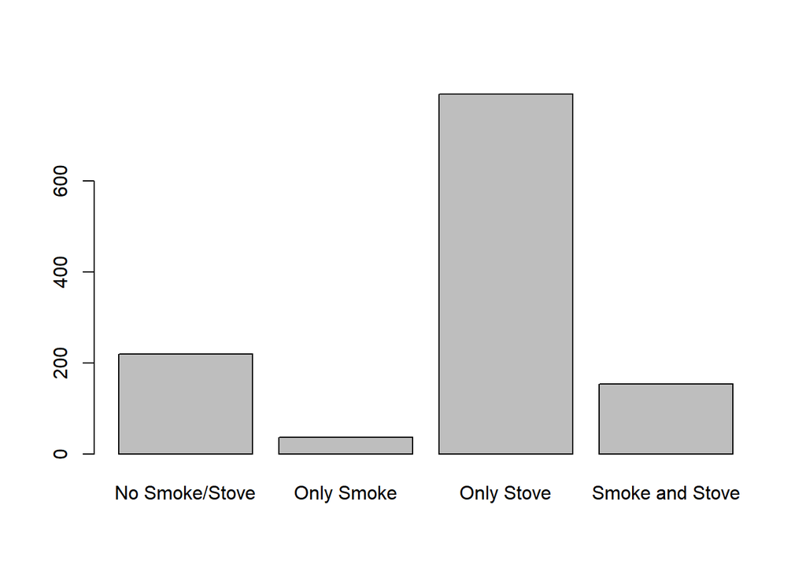

```r
barplot(table(chsdata$smoke_gas_exposure))
```

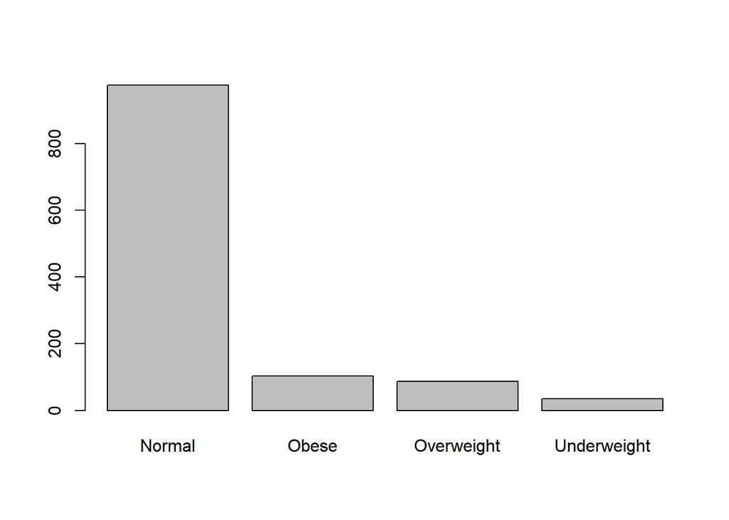

```r
barplot(table(chsdata$obesity_level))
```

```r
summary(chsdata$bmi)
```

```
   Min. 1st Qu.  Median    Mean 3rd Qu.    Max.
  11.30   15.96   17.81   18.50   19.99   41.27
```

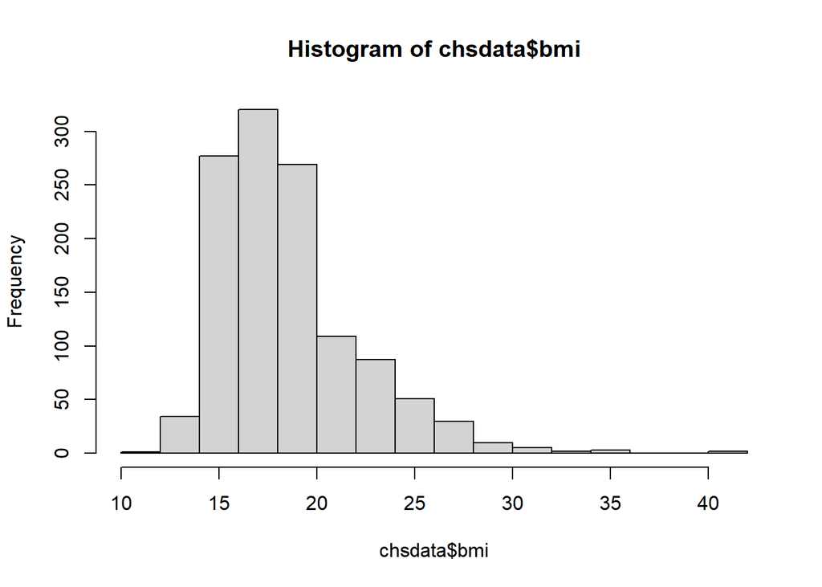

```r
hist(chsdata$bmi)
```

```r
summary(chsdata$fev)
```

```
   Min. 1st Qu.  Median    Mean 3rd Qu.    Max.
  984.8  1827.6  2016.4  2030.1  2223.6  3323.7
```

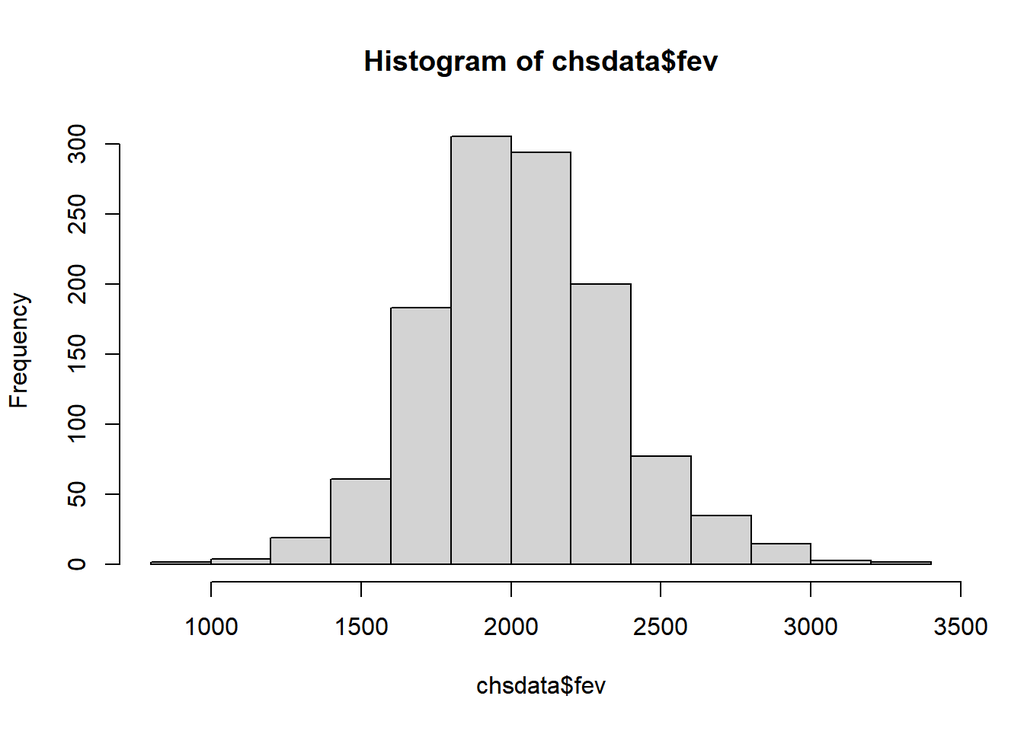

```r
hist(chsdata$fev)
```

```r
summary(chsdata$pm25_mass)
```

```
   Min. 1st Qu.  Median    Mean 3rd Qu.    Max.
  5.960   7.615  10.545  14.362  20.988  29.970
```

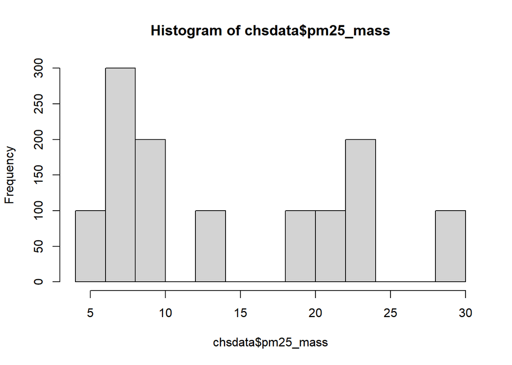

```r
hist(chsdata$pm25_mass)
```

```r
#no variables seem to have implausible values
#important variables = bmi, fev, smoke_gas_exposure, pm25_mass

missing <- colSums(is.na(chsdata))
missing
```

```
          townname                sid               male               race
                 0                  0                  0                  0
          hispanic             agepft             height             weight
                 0                  0                  0                  0
               bmi             asthma      active_asthma      father_asthma
                 0                  0                  0                  0
     mother_asthma             wheeze           hayfever            allergy
                 0                  0                  0                  0
       educ_parent              smoke               pets           gasstove
                 0                  0                  0                  0
               fev                fvc               mmef          pm25_mass
                 0                  0                  0                  0
          pm25_so4           pm25_no3           pm25_nh4            pm25_oc
                 0                  0                  0                  0
           pm25_ec            pm25_om            pm10_oc            pm10_ec
                 0                  0                  0                  0
           pm10_tc             formic             acetic                hcl
                 0                  0                  0                  0
              hno3             o3_max              o3106              o3_24
                 0                  0                  0                  0
               no2               pm10            no_24hr           pm2_5_fr
                 0                  0                  0                  0
             iacid              oacid        total_acids                lon
                 0                  0                  0                  0
               lat      obesity_level smoke_gas_exposure
                 0                  0                  0
```

## Exploratory Plots

### What is the association between BMI and FEV?

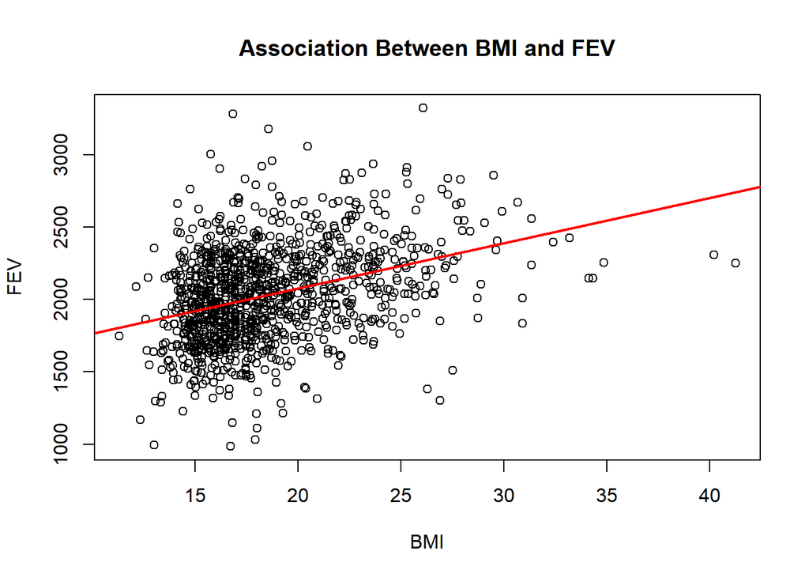

```r
mod <- lm(fev ~ bmi, data = chsdata)
plot(chsdata$bmi, chsdata$fev,
  main = "Association Between BMI and FEV",
  xlab = "BMI", ylab = "FEV")
abline(mod, lwd = 2, col = "red")
```

There is a positive association between BMI and FEV at first glance.

### What is the association between smoke and gas exposure and FEV?

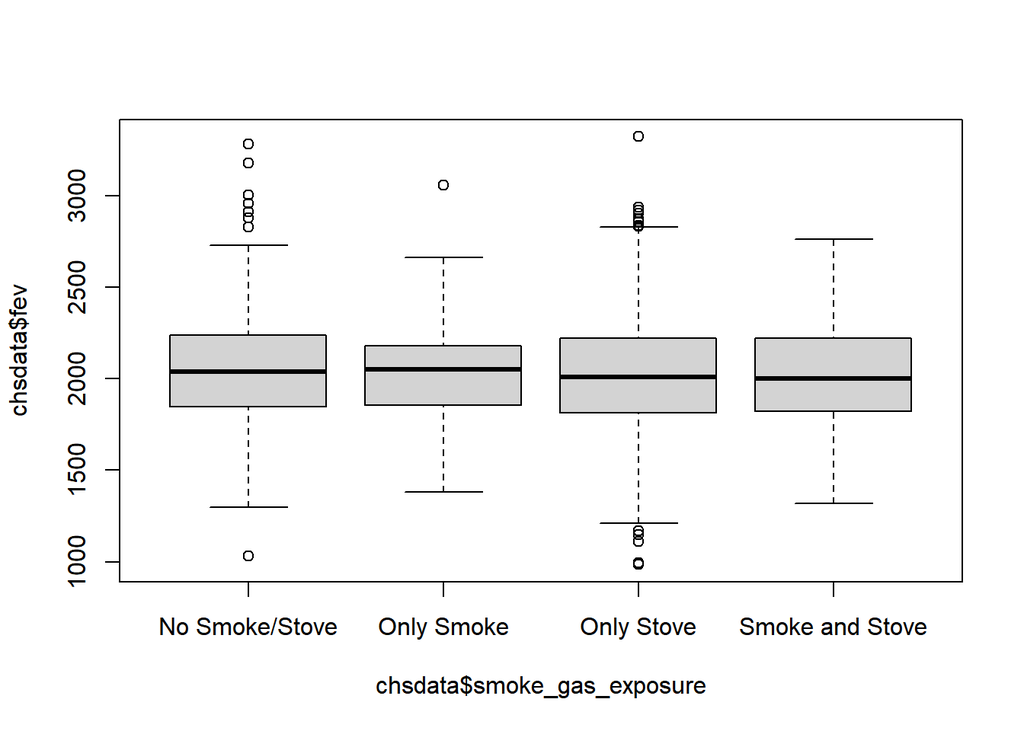

```r
library(ggplot2)
boxplot(chsdata$fev ~ chsdata$smoke_gas_exposure)
```

There does not seem to be an association between smoke and gas exposure and FEV at first glance.

### What is the association between PM2.5 exposure and FEV?

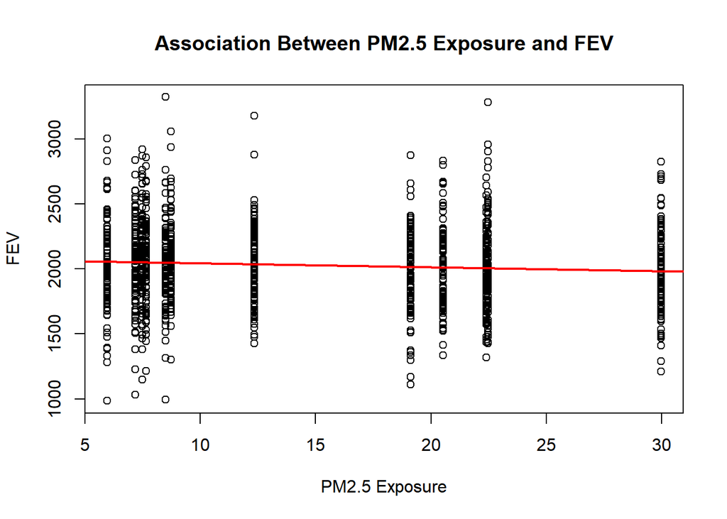

```r
mod <- lm(fev ~ pm25_mass, data = chsdata)
plot(chsdata$pm25_mass, chsdata$fev,
  main = "Association Between PM2.5 Exposure and FEV",
  xlab = "PM2.5 Exposure", ylab = "FEV")
abline(mod, lwd = 2, col = "red")
```

There does not seem to be a great association between PM2.5 mass exposure and FEV at first glance, although there may be a small negative association.

## 3. Visualization

### 1. Facet plot showing scatter plots with regression lines of BMI vs FEV by town name

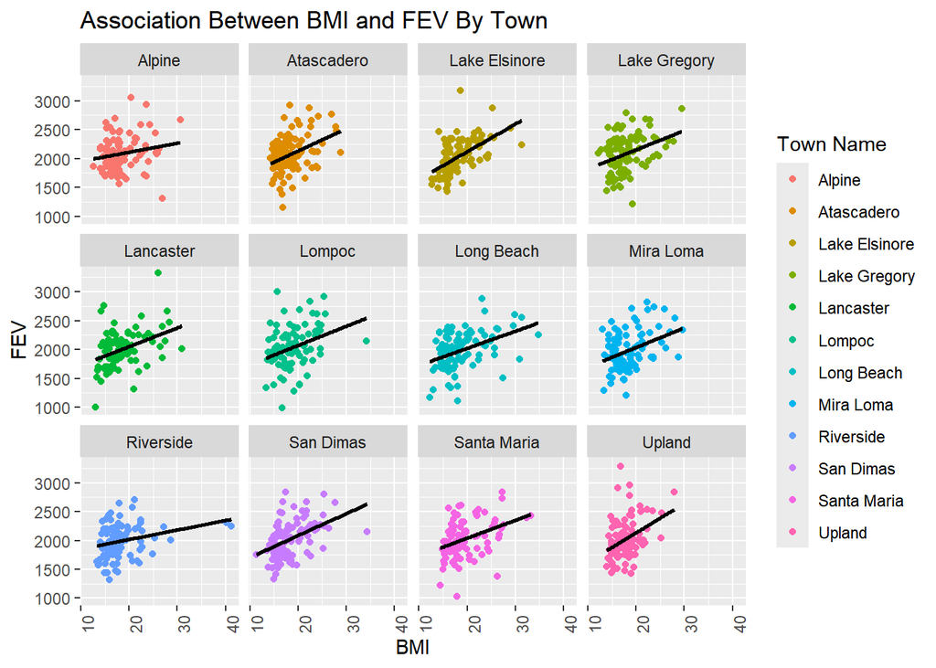

```r
library(ggplot2)
chsdata[!is.na(smoke_gas_exposure) & !is.na(fev) & !is.na(townname)] |>
  ggplot(mapping = aes(x = bmi, y = fev, color = townname)) +
  geom_point() +
  geom_smooth(method = lm, se = FALSE, col = "black") +
  facet_wrap(~ townname, nrow = 3, ncol = 4) +
  theme(axis.text.x = element_text(angle = 90)) +
  labs(title = "Association Between BMI and FEV By Town") +
  labs(x = "BMI", y = "FEV", color = "Town Name")
```

According to the scatter plots, there seems to be a positive association between BMI and FEV in each of the different towns.

### 2. Stacked histograms of FEV by BMI category and FEV by smoke/gas exposure. Use different color schemes than the ggplot default.

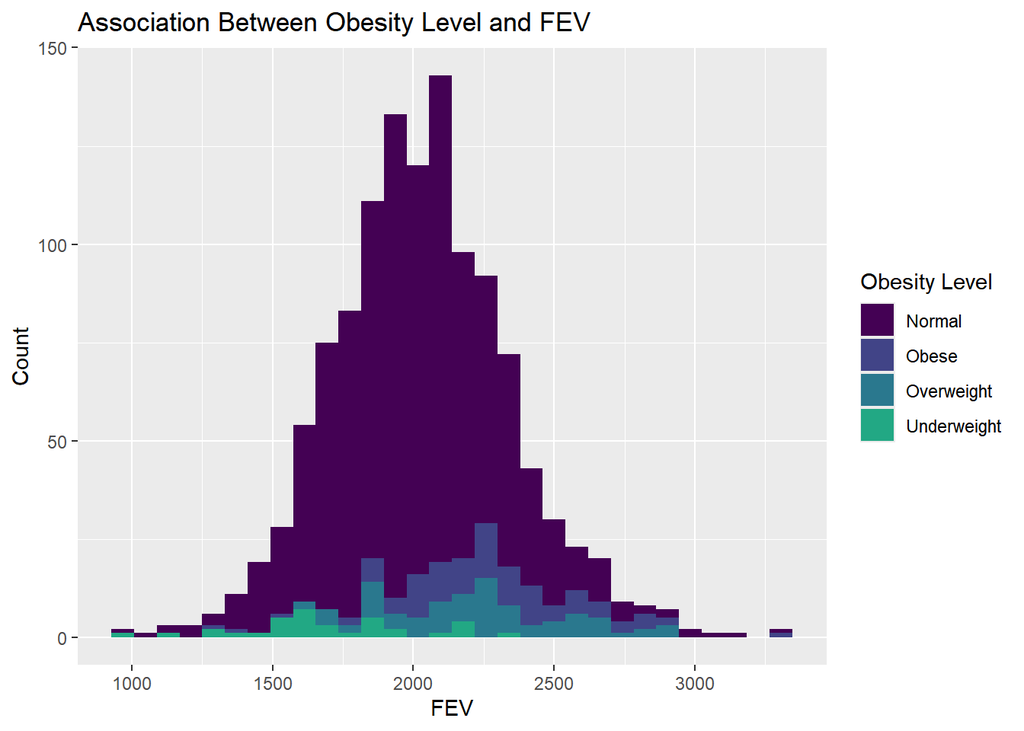

```r
chsdata[!is.na(obesity_level) & !is.na(fev)] |>
  ggplot(mapping = aes(x = fev, fill = obesity_level)) +
  geom_histogram(position = "stack") +
  scale_fill_manual(values = viridis::viridis(6)) +
  labs(title = "Association Between Obesity Level and FEV") +
  labs(x = "FEV", y = "Count", fill = "Obesity Level")
```

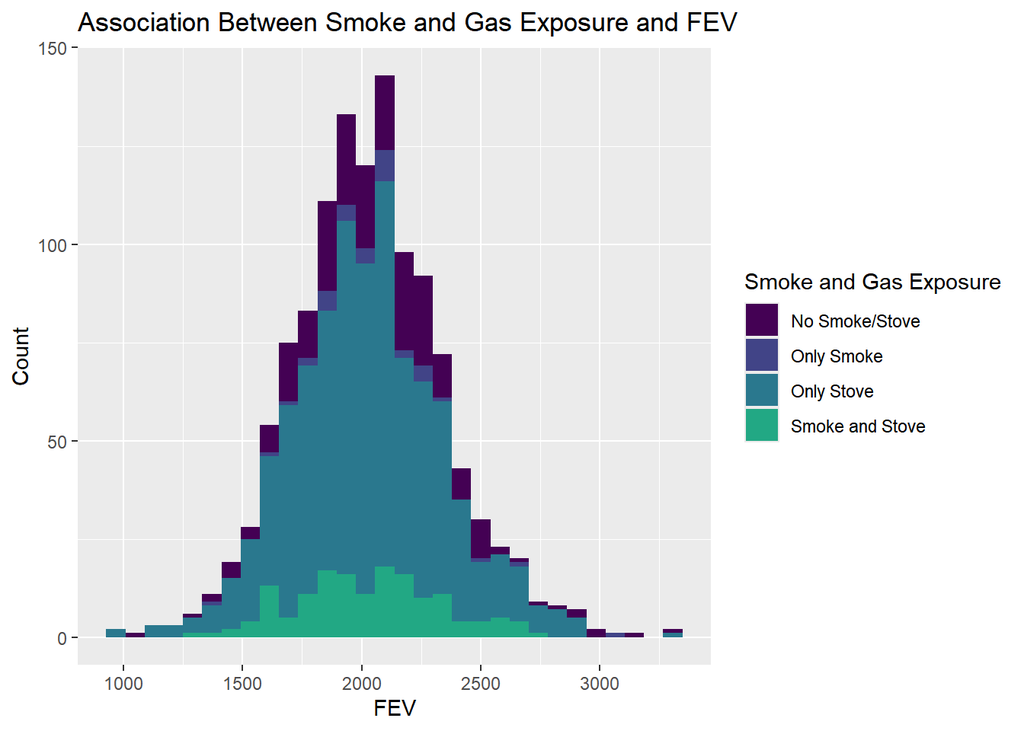

```r
chsdata[!is.na(fev) & !is.na(smoke_gas_exposure)] |>
  ggplot(mapping = aes(x = fev, fill = smoke_gas_exposure)) +
  geom_histogram(position = "stack") +
  scale_fill_manual(values = viridis::viridis(6)) +
  labs(title = "Association Between Smoke and Gas Exposure and FEV") +
  labs(x = "FEV", y = "Count", fill = "Smoke and Gas Exposure")
```

### 3. Barchart of BMI by smoke/gas exposure.

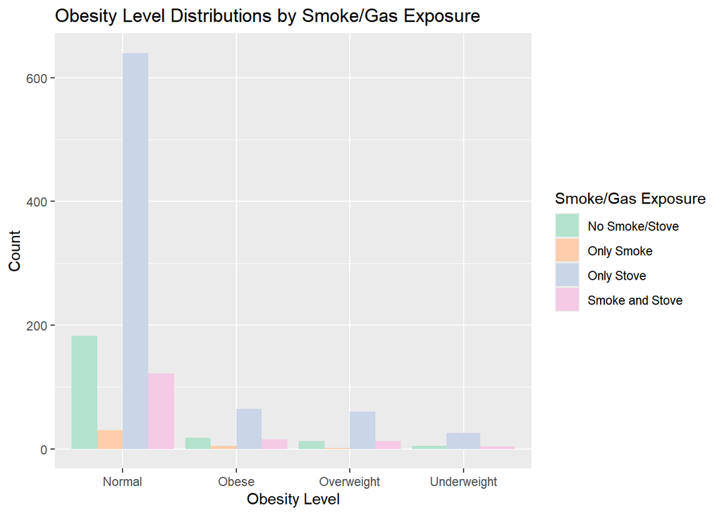

```r
chsdata[!is.na(bmi) & !is.na(smoke_gas_exposure)] |>
  ggplot(mapping = aes(x = obesity_level, fill = smoke_gas_exposure)) +
  geom_bar(position = "dodge") +
  labs(title = "Obesity Level Distributions by Smoke/Gas Exposure") +
  labs(x = "Obesity Level", y = "Count", fill = "Smoke/Gas Exposure") +
  scale_fill_brewer(palette = "Pastel2")
```

For every obesity level, the greatest exposure has been to gas stoves, followed by no smoke or gas stove exposure. However, every obesity level seems to follow the same distribution pattern, with obese, overweight, and underweight having less counts due to the majority of observations coming from normal persons. Due to the same distribution pattern, there does not seem to be an association between obesity level and smoke/gas exposure.

### 4. Statistical summary graphs of FEV by BMI and FEV by smoke/gas exposure category.

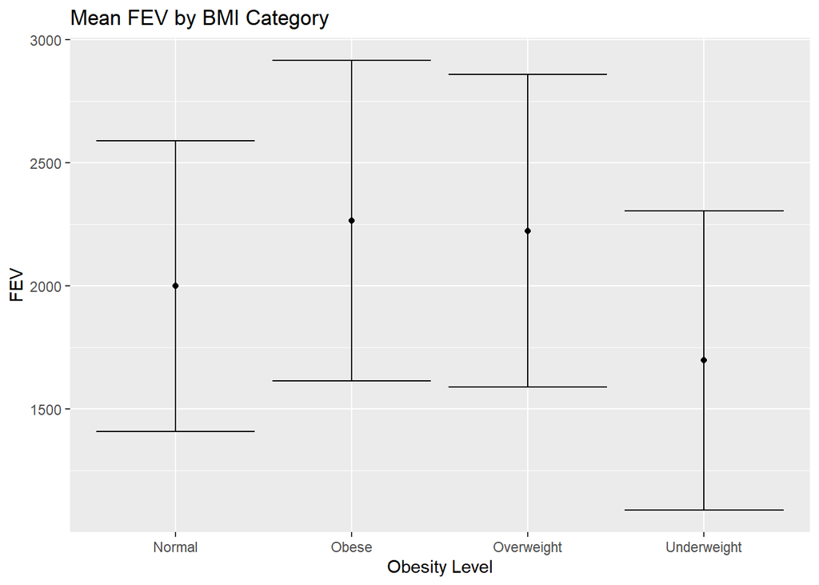

```r
library(Hmisc)
chsdata[!is.na(fev) & !is.na(bmi)] |>
  ggplot() +
  stat_summary(mapping = aes(x = obesity_level, y = fev),
               fun = mean,
               geom = "point") +
  stat_summary(mapping = aes(x = obesity_level, y = fev),
               fun.data = "mean_sdl",
               geom = "errorbar") +
  labs(title = "Mean FEV by BMI Category",
       x = "Obesity Level",
       y = "FEV")
```

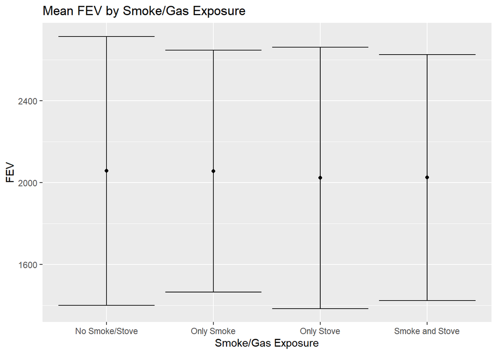

```r
chsdata[!is.na(fev) & !is.na(smoke_gas_exposure)] |>
  ggplot() +
  stat_summary(mapping = aes(x = smoke_gas_exposure, y = fev),
               fun = mean,
               geom = "point") +
  stat_summary(mapping = aes(x = smoke_gas_exposure, y = fev),
               fun.data = "mean_sdl",
               geom = "errorbar") +
  labs(title = "Mean FEV by Smoke/Gas Exposure",
       x = "Smoke/Gas Exposure",
       y = "FEV")
```

Mean FEV seems to differ according to obesity level, with obese and overweight persons having a greater mean FEV, followed by normal, and then underweight. In other words, as obesity level increases, the mean FEV increases, showing a positive association. However, as the error bars all overlap, the difference is not statistically significant. On the other hand, the mean FEV for all smoke/gas exposure categories is similar, so there does not seem to be an association between smoke/gas exposure and FEV.

### 5. A leaflet map showing the concentrations of PM2.5 mass in each of the CHS communities.

```r
library(leaflet)
pm25.pal <- colorNumeric(c('green', 'yellow', 'red'), domain=chsdata$pm25_mass)
pm25.pal
```

[output not shown]

```r
pmmap <-leaflet(chsdata) |>
  addProviderTiles('CartoDB.Positron') |>
  addCircles(
    lat = ~lat, lng = ~lon,
    color = ~pm25.pal(pm25_mass),
    opacity = 1, fillOpacity = 1, radius = 500
  ) |>
  addLegend('bottomleft', pal=pm25.pal, values = chsdata$pm25_mass,
            title = 'PM2.5 Mass', opacity = 1)

pmmap
```

[interactive chart not shown]

Mira Loma seems to have the highest PM2.5 mass, followed by Riverside, Upland, San Dimas, and Long Beach. The other towns have lower PM2.5 masses less than 15.

### 6. Choose a visualization to examine whether PM2.5 mass is associated with FEV.

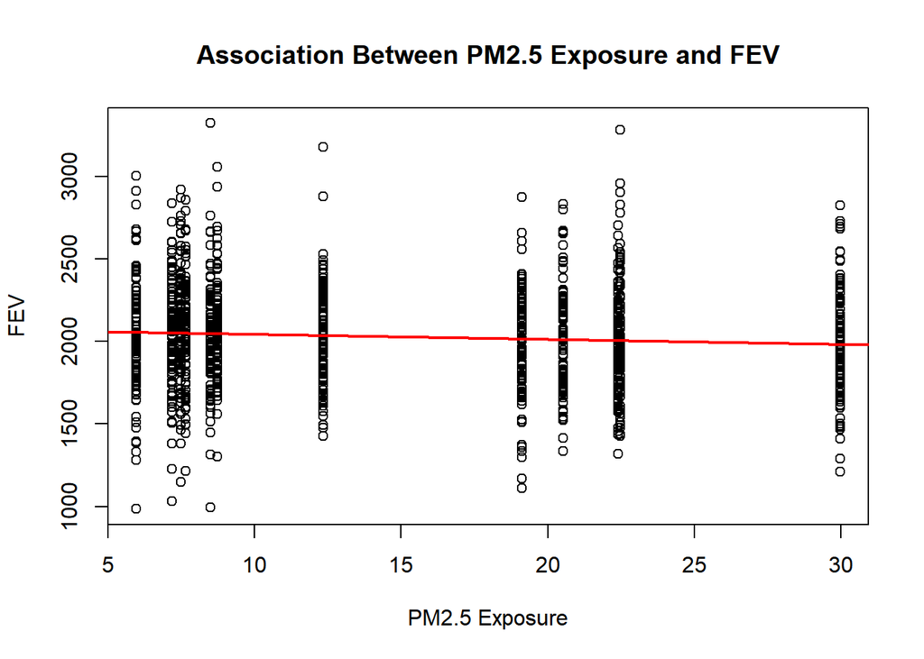

```r
mod <- lm(fev ~ pm25_mass, data = chsdata)
plot(chsdata$pm25_mass, chsdata$fev,
  main = "Association Between PM2.5 Exposure and FEV",
  xlab = "PM2.5 Exposure", ylab = "FEV")
abline(mod, lwd = 2, col = "red")
```

```r
summary(mod)
```

```
Call:
lm(formula = fev ~ pm25_mass, data = chsdata)

Residuals:
     Min       1Q   Median       3Q      Max
-1070.63  -206.57   -13.33   195.87  1277.65

Coefficients:
            Estimate Std. Error t value Pr(>|t|)
(Intercept) 2073.452     19.309 107.383   <2e-16 ***
pm25_mass     -3.016      1.184  -2.548    0.011 *
---
Signif. codes:  0 '***' 0.001 '**' 0.01 '*' 0.05 '.' 0.1 ' ' 1

Residual standard error: 317.3 on 1198 degrees of freedom
Multiple R-squared:  0.005389,  Adjusted R-squared:  0.004559
F-statistic: 6.492 on 1 and 1198 DF,  p-value: 0.01096
```

Reusing the plot from my exploratory analysis, we can see that there is a small negative association between PM2.5 mass exposure and FEV. This association is significant at the 0.05 level (p = 0.01096).

## 4. Summary

Let’s review our three main questions: 1) What is the association between BMI and FEV (forced expiratory volume)? 2) What is the association between smoke and gas exposure and FEV? and 3) What is the association between PM2.5 exposure and FEV? According to our statistical summary graph relating mean FEV and obesity level, we can see that as obesity level increases, the mean FEV increases, showing a positive association between the two variables. On the other hand, there does not seem to be an association between smoke and gas exposure and FEV as the mean FEVs were similar for all smoke and gas exposure categories. Lastly, there seems to be a negative association between PM2.5 exposure and FEV, shown by the negative slope of the regression line on the scatter plot relating the two variables.